# Análisis de datos de RNA-Seq

Especialización en Bioinformática - UNR

Estefania Mancini

29 de Marzo 2022

# Alineamiento contra referencia

El siguiente paso a realizar es alinear las lecturas contra una referencia. En este punto tenemos muchas alternativas y depende esencialmente:

- De la disponibilidad de la anotación del genoma / transcriptoma del organismo en estudio,
- de la pregunta biológica que queremos resolver.

El resultado del alineamiento contra referencia normalmente se guarda en archivos de formato BAM.

En este práctico trabajaremos con los datos públicos del paquete de R/Bioconductor **RNAseqData.HNRNPC.bam.chr14**. El paquete contiene 8 archivos BAM, 1 por cada corrida.

Cada archivo **BAM** se obtuvo: 1. Alineando las lecturas al total del genoma Homo Sapiens v hg19 con topHat 2. Subseteando sólo las lecturas que alinearon al cromosoma 14.

## Tabla de conteos

Luego del alineamiento hay que contar cuántas lecturas han caı́do en cada región de interés y dependerá nuevamente de nuestra pregunta biológica y de la referencia contra la que hayamos decidido alinear.

En nuestro caso exploraremos los resultados utilizando el paquete de R **edegR** que aplica para el modelo **count based**.

Por cuestiones de tiempo el paso del armado de las tablas ya fue resuelto ejecutando los siguientes comandos:

```r
library(RNAseqData.HNRNPC.bam.chr14)
library(GenomicRanges)
library(GenomicFeatures)
library(GenomicAlignments)
bamfiles <- RNAseqData.HNRNPC.bam.chr14_BAMFILES
targets <-
    data.frame(
        row.names = names(RNAseqData.HNRNPC.bam.chr14_BAMFILES),
        bam = matrix(
            unlist(RNAseqData.HNRNPC.bam.chr14_BAMFILES),
            ncol = 1,
            byrow = TRUE
        ),
        condition = c(rep("CT", 4), rep("KD", 4))
    )
write.table(targets, "targets.txt", quote = F, sep = "\t")

files = as.character(targets$bam)

reads <- lapply(files,
                function(x) {
                    aln <- readGAlignments(x)
                })
names(reads) <- rownames(targets)

c14 <- makeTxDbFromGFF("chr14.gtf")
saveDb(c14 ,"chr14.sqlite")

feature <- exonsBy(c14, by = "gen")
hits <-
    lapply(reads, function(x) {
        countOverlaps(feature, x, ignore.strand = TRUE)
    })
hits.ul <- do.call(cbind.data.frame, hits)
write.table(file = "genes.hits.txt", hits.ul)
```

# Detección de genes diferencialmente expresados

Una vez que tenemos las tablas de conteos hay que realizar el análisis de los datos para buscar aquellos genes que se hayan comportado diferente en las condicones en estudio. En este caso, analizaremos datos de un trabajo cuyo objetivo es analizar el impacto sobre la remodelación del transcriptoma ante el silenciamiento de una proteı́na del spliceosoma (hnRNPC).

El diseño experimental es una comparación entre **2 condiciones**, con **4 réplicas** biológicas cada una.

Antes de empezar armamos un archivo *targets* o *mapping file* donde se detalla cada muestra a qué condición corresponde

```r
targets <- read.table("~/Documents/UNR/clases/data/HNRPC/targets.txt", header = T, row.names = 1)
```

Ahora cargaremos la tabla de counts a nivel gen. Especificamos algunas opciones tales como cuál es la colunma que le da nombre a las filas *(row.names = 1)*, así como si los nombres de las columnas. Para saber sobre estas especificaciones puede consultar el help de *read.table*.

```r
counts <-
    read.table(
        "~/Documents/UNR/clases/data/HNRPC/genes.hits.txt",
        row.names = 1,
        header = T,
        stringsAsFactors = F
    )
```

¿Qué tipo de objeto es **counts**? ¿Qué dimensiones tiene? ¿Cómo luce?

```r
class(counts)
```

```
## [1] "data.frame"
```

```r
dim(counts)
```

```
## [1] 782   8
```

```r
head(counts)
```

```
##         ERR127306 ERR127307 ERR127308 ERR127309 ERR127302 ERR127303 ERR127304
## ABCD4         784       699       760       668       562       508       680
## ABHD12B         1         6         0         1         2         3         8
## ABHD4        1134      1236      1257      1028       807       732       900
## ACIN1        5038      5659      5699      4980      5020      4996      6308
## ACOT1         837       836       873       754       441       462       693
## ACOT2        1878      1878      2079      1771       858       847      1330
##         ERR127305
## ABCD4         723
## ABHD12B        10
## ABHD4         891
## ACIN1        6174
## ACOT1         610
## ACOT2        1263
```

Cargamos al entorno el paquete de bioconductor con el que vamos a realizar nuestro primer análisis en busca de genes diferencialmente expresdos:

```r
library(edgeR)
```

Para explorar un poco la tabla de datos, miremos algunas medidas resumen y la distribucion de los counts:

```r
summary(counts)
```

```
##    ERR127306         ERR127307         ERR127308         ERR127309
##  Min.   :    0.0   Min.   :    0.0   Min.   :    0.0   Min.   :    0.0
##  1st Qu.:    0.0   1st Qu.:    0.0   1st Qu.:    0.0   1st Qu.:    0.0
##  Median :   62.5   Median :   78.5   Median :   72.0   Median :   64.5
##  Mean   :  882.2   Mean   :  966.8   Mean   :  962.8   Mean   :  859.1
##  3rd Qu.:  679.2   3rd Qu.:  790.0   3rd Qu.:  760.0   3rd Qu.:  695.2
##  Max.   :72708.0   Max.   :74195.0   Max.   :80599.0   Max.   :65570.0
##    ERR127302         ERR127303         ERR127304         ERR127305
##  Min.   :    0.0   Min.   :    0.0   Min.   :    0.0   Min.   :    0.0
##  1st Qu.:    0.0   1st Qu.:    0.0   1st Qu.:    0.0   1st Qu.:    0.0
##  Median :   44.5   Median :   47.0   Median :   51.5   Median :   55.0
##  Mean   :  811.3   Mean   :  857.0   Mean   :  861.1   Mean   :  855.4
##  3rd Qu.:  647.8   3rd Qu.:  705.2   3rd Qu.:  810.0   3rd Qu.:  767.0
##  Max.   :56502.0   Max.   :57770.0   Max.   :59903.0   Max.   :63870.0
```

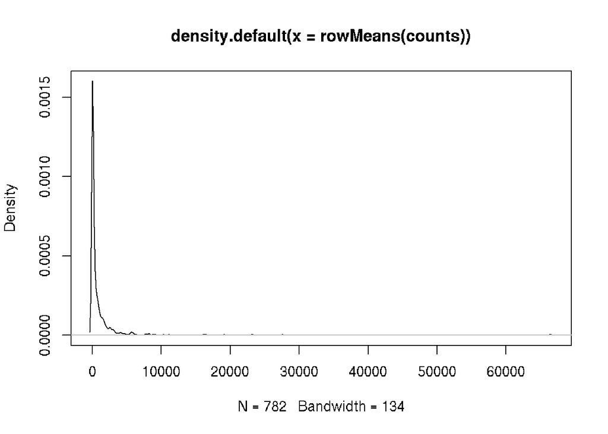

```r
plot(density(rowMeans(counts)))
```

Podemos refinar un poco el gráfico:

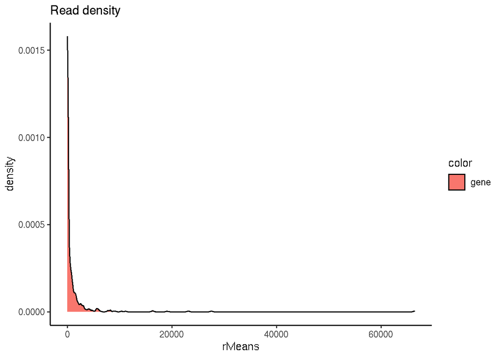

```r
library(ggplot2)
dreads<-density(rowMeans(counts))
rmeans<-data.frame(rMeans=rowMeans(counts))
rmeans$color<-rep("gene", nrow(rmeans))

 ggplot(rmeans, aes(x=rMeans, fill=color)) +
 geom_density()+
  theme_classic()+
  labs(title="Read density")
```

También podemos explorar usando boxplots de cada una de las muestras para ir conociendo nuestros datos:

```r
par(mfrow=c(2,4))
apply(counts, 2, boxplot)
```

[output not shown]

Con un poco más de calidad:

```r
library(reshape2)
 df<- melt(counts)
```

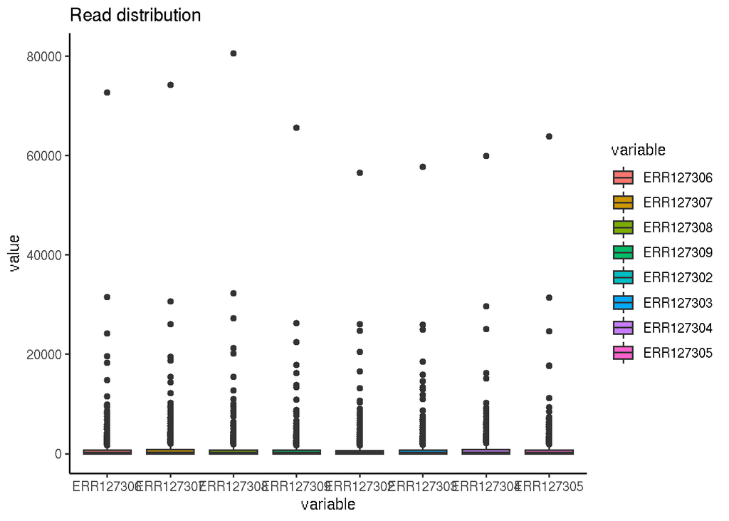

```r
ggplot(df, aes(x=variable, y=value, fill=variable)) +
  geom_boxplot()+
  theme_classic()+
  labs(title="Read distribution")
```

- ¿Cómo son nuestros datos?

# Filtros

*Cuidado porque acá la columna 1 tiene el símbolo del gen*

```r
cpms<-cpm(counts[,1:ncol(counts)])
```

Armamos un nuevo objeto y sobre el realizamos el filtro:

```r
keep<-rowSums(cpms>1)>4
```

¿Qué tipo de vector es **keep**? ¿Para qué voy a utilizarlo? ¿Qué longitud tiene? ¿Cuántos valores son **TRUE**?

Controlemos la dimensión de la matriz original y filtrada, una vez que subseteamos con el vector **keep**:

```r
dim(counts)
```

```
## [1] 782   8
```

```r
countsf<-counts[keep,]
dim(countsf)
```

```
## [1] 479   8
```

Repetimos las medidas resumen y gráficos exploratorios:

```r
summary(countsf)
```

```
##    ERR127306       ERR127307       ERR127308       ERR127309
##  Min.   :    0   Min.   :    0   Min.   :    0   Min.   :    0.0
##  1st Qu.:  126   1st Qu.:  147   1st Qu.:  142   1st Qu.:  124.5
##  Median :  467   Median :  548   Median :  534   Median :  498.0
##  Mean   : 1440   Mean   : 1578   Mean   : 1572   Mean   : 1402.4
##  3rd Qu.: 1332   3rd Qu.: 1539   3rd Qu.: 1432   3rd Qu.: 1362.0
##  Max.   :72708   Max.   :74195   Max.   :80599   Max.   :65570.0
##    ERR127302       ERR127303         ERR127304         ERR127305
##  Min.   :    0   Min.   :    0.0   Min.   :    0.0   Min.   :    0.0
##  1st Qu.:  111   1st Qu.:  125.5   1st Qu.:  118.5   1st Qu.:  101.5
##  Median :  441   Median :  490.0   Median :  547.0   Median :  476.0
##  Mean   : 1324   Mean   : 1399.1   Mean   : 1405.8   Mean   : 1396.4
##  3rd Qu.: 1162   3rd Qu.: 1332.5   3rd Qu.: 1445.5   3rd Qu.: 1419.5
##  Max.   :56502   Max.   :57770.0   Max.   :59903.0   Max.   :63870.0
```

Ahora si, tenemos la tabla de conteos filtrados. Para comenzar a trabajar creamos un objeto de tipo **DGELis**t que es propio del paquete **edgeR**. tenemos que pasarle los conteos y un vector factorial con las condiciones de cada muestra.

*Importante: Hay que chequear que el vector con las condiciones o grupo, coincida con nuestras muestras.*

```r
d<-DGEList(counts=countsf, group=targets$condition)
str(d)
```

```
## Formal class 'DGEList' [package "edgeR"] with 1 slot
##   ..@ .Data:List of 2
##   .. ..$ : int [1:479, 1:8] 784 1 1134 5038 837 1878 18340 340 97 4 ...
##   .. .. ..- attr(*, "dimnames")=List of 2
##   .. .. .. ..$ : chr [1:479] "ABCD4" "ABHD12B" "ABHD4" "ACIN1" ...
##   .. .. .. ..$ : chr [1:8] "ERR127306" "ERR127307" "ERR127308" "ERR127309" ...
##   .. ..$ :'data.frame':  8 obs. of  3 variables:
##   .. .. ..$ group       : Factor w/ 2 levels "CT","KD": 1 1 1 1 2 2 2 2
##   .. .. ..$ lib.size    : num [1:8] 689867 756007 752857 671768 634424 ...
##   .. .. ..$ norm.factors: num [1:8] 1 1 1 1 1 1 1 1
```

Exploremos el objeto. Es un objeto de tipo *lista*, pero propia de **edgeR**. Cada uno de los componentes en este caso se denomina slot.

¿Qué información sobre nuestras muestras se ha incorporado en este objeto?

## Estimación de los factores de normalización

- La cantidad de lecturas que son contadas por gen son proporcionales a su longitud y a su expresión. Si quisiéramos tener una medida de la expresión absoluta habrı́a que tener en cuenta la longitud.
- En este análisis estamos concentrados en evaluar las diferencias de expresión entre 2 condiciones. Sólo se tienen en cuenta factores técnicos que deben ser corregidos antes de llevar a cabo el análisis de expresión diferencial.
- El más influyente es el que se denomina profundidad de la corrida es corregido teniendo en cuenta el tamaño de la biblioteca.
- Otro factor que es importante es la çomposición de la biblioteca: hay genes muy expresados que consumen muchas lecturas causando que los demás genes menos expresados sean subsampleados. Sobre el objeto, calcularemos los factores de normalización. Volver a explorar el objeto original y observar qué cambios se produjeron.

```r
d<-calcNormFactors(d)
d
```

```
## An object of class "DGEList"
## $counts
##         ERR127306 ERR127307 ERR127308 ERR127309 ERR127302 ERR127303 ERR127304
## ABCD4         784       699       760       668       562       508       680
## ABHD12B         1         6         0         1         2         3         8
## ABHD4        1134      1236      1257      1028       807       732       900
## ACIN1        5038      5659      5699      4980      5020      4996      6308
## ACOT1         837       836       873       754       441       462       693
##         ERR127305
## ABCD4         723
## ABHD12B        10
## ABHD4         891
## ACIN1        6174
## ACOT1         610
## 474 more rows ...
##
## $samples
##           group lib.size norm.factors
## ERR127306    CT   689867    0.9478567
## ERR127307    CT   756007    0.9943495
## ERR127308    CT   752857    0.9649159
## ERR127309    CT   671768    1.0011559
## ERR127302    KD   634424    0.9544481
## ERR127303    KD   670163    0.9931018
## ERR127304    KD   673379    1.1156889
## ERR127305    KD   668861    1.0385750
```

## Relación entre réplicas

Tenemos una función para explorar las muestras con un gráfico de bajas dimensiones (tipo PCA)

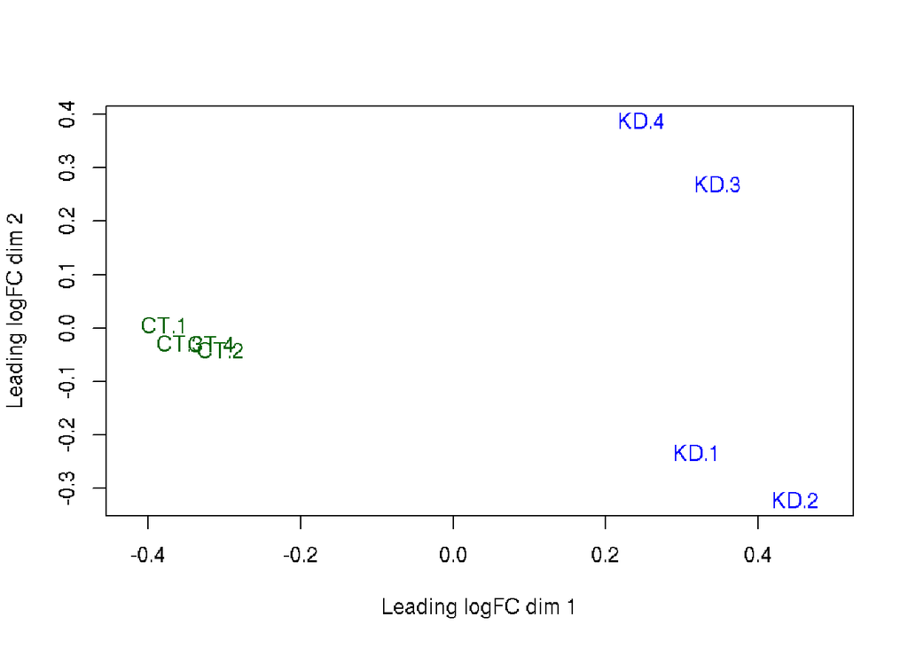

```r
shortNames<-paste(targets$condition, rep(1:4, 2), sep=".")
targets<-cbind(targets,shortNames)

plotMDS(d, labels=targets$shortNames,
col=c("darkgreen","blue")[factor(targets$condition)])
```

- Esta función calculará las distancias euclı́deas entre cada para de muestras y representará en un gráfico de 2 dimensiones cómo es la relación entre las muestras. * Podemos observar si en el experimento la separación entre condiciones es suficientemente robusta y cómo es la relación entre las réplicas.

## Dispersión

Primero estimaremos la dispersión común a todas las bibliotecas:

```r
d<-estimateCommonDisp(d, verbose=TRUE)
```

```
## Disp = 0.03265 , BCV = 0.1807
```

- En este caso la dispersión tiene 2 componentes: la técnica y la biológica. La biológica es la raı́z cuadrada de la dispersión.
- Si analizamos cómo se comporta el Coeficiente de variación Biológica, vemos que es superior a la dispersión común a bajas concentraciones de lecturas. Esto hace que sea más apropiado, establecer una dispersión gen a gen y no utilizar la misma dispersión común para todos.

```r
d<-estimateTagwiseDisp(d)
d
```

```
## An object of class "DGEList"
## $counts
##         ERR127306 ERR127307 ERR127308 ERR127309 ERR127302 ERR127303 ERR127304
## ABCD4         784       699       760       668       562       508       680
## ABHD12B         1         6         0         1         2         3         8
## ABHD4        1134      1236      1257      1028       807       732       900
## ACIN1        5038      5659      5699      4980      5020      4996      6308
## ACOT1         837       836       873       754       441       462       693
##         ERR127305
## ABCD4         723
## ABHD12B        10
## ABHD4         891
## ACIN1        6174
## ACOT1         610
## 474 more rows ...
##
## $samples
##           group lib.size norm.factors
## ERR127306    CT   689867    0.9478567
## ERR127307    CT   756007    0.9943495
## ERR127308    CT   752857    0.9649159
## ERR127309    CT   671768    1.0011559
## ERR127302    KD   634424    0.9544481
## ERR127303    KD   670163    0.9931018
## ERR127304    KD   673379    1.1156889
## ERR127305    KD   668861    1.0385750
##
## $common.dispersion
## [1] 0.03265052
##
## $pseudo.counts
##           ERR127306   ERR127307 ERR127308  ERR127309   ERR127302   ERR127303
## ABCD4    825.410088  640.090656  720.3328  683.89470  639.008396  525.628495
## ABHD12B    1.075742    5.657908    0.0000    1.03437    2.441196    3.140145
## ABHD4   1194.031833 1132.058375 1191.4237 1052.46231  917.460022  757.339736
## ACIN1   5304.837099 5183.167365 5401.5765 5098.37365 5708.139847 5168.622039
## ACOT1    881.268926  765.632524  827.4471  771.93950  501.650158  478.028819
##           ERR127304   ERR127305
## ABCD4    623.188884  716.634885
## ABHD12B    7.382666    9.927443
```

[output cut: 9 more lines]

```
## [1]  9.934528  3.085891 10.498620 12.956426  9.959084
## 474 more elements ...
##
## $prior.df
## [1] 10
##
## $prior.n
## [1] 1.666667
##
## $tagwise.dispersion
## [1] 0.01995358 0.14328152 0.01699446 0.02175504 0.01952126
## 474 more elements ...
##
## $span
## [1] 0.3
```

Y analizar la nube de puntos gráficamente, con la función **plotBCV**

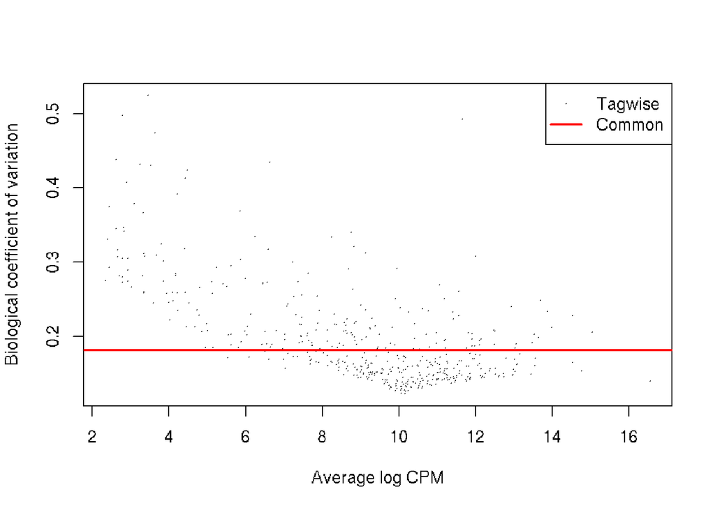

```r
plotBCV(d)
```

# Expresión diferencial

Ya estamos en condiciones de testear la expresión diferencial. Para ello **edegR** tiene la función **exactTest**. La misma necesitará la dispersión que acabamos de calcular y el par que queremos comparar. Este es un test que se utiliza para evaluar diferencias entre pares, bajo una distribución binomial negativa. Como resultado del test, obtenemos los *pvalues* para cada comparación. El resultado del test lo guardamos en un objeto nuevo **de**.

```r
de<-exactTest(d, pair=c("CT","KD"))
str(de)
```

```
## Formal class 'DGEExact' [package "edgeR"] with 1 slot
##   ..@ .Data:List of 3
##   .. ..$ :'data.frame':  479 obs. of  3 variables:
##   .. .. ..$ logFC : num [1:479] -0.196 1.504 -0.434 0.118 -0.548 ...
##   .. .. ..$ logCPM: num [1:479] 9.93 3.09 10.5 12.96 9.96 ...
##   .. .. ..$ PValue: num [1:479] 0.190512 0.039602 0.001575 0.435302 0.000222 ...
##   .. ..$ : chr [1:2] "CT" "KD"
##   .. ..$ : NULL
```

¿Qué tenemos en el objeto **de**?

Con la función **topTags** se ordenarán los genes por su *pvalue* corregido. Se muestran los top 10:

```r
tt <- topTags(de)
tt
```

```
## Comparison of groups:  KD-CT
##               logFC    logCPM        PValue           FDR
## HNRNPC    -4.881607 12.003483 9.679822e-115 4.636635e-112
## EXOC3L4   -3.615570  7.479110  4.090635e-44  9.797071e-42
## NFATC4    -2.606747  8.123275  1.741705e-26  2.730527e-24
## FOXN3      1.552703 10.221702  2.280190e-26  2.730527e-24
## IRF2BPL   -1.756416 11.256151  3.879179e-26  3.716253e-24
## ARHGEF40  -1.579881  9.970989  1.017017e-20  8.119189e-19
## ZFHX2     -1.956121  7.941734  7.753305e-20  5.305476e-18
## LINC00641 -2.284144  6.510926  4.784986e-17  2.865010e-15
## PAPLN     -1.398384 10.952132  4.472029e-15  2.246202e-13
## HSPA2     -1.289953 11.431966  4.689356e-15  2.246202e-13
```

También odemos extraer la cantidad que especifiquemos, por ejemplo TODOS los genes.

```r
tt <- topTags(de, n = nrow(de))
```

*¿Cuál es el gen que está más afectado en este experimento? ¿Tiene lógica?*

Podemos explorar rápidamente cómo se distribuyeron los *pvalues*:

```r
table(tt$table$FDR <0.05)
```

```
##
## FALSE  TRUE
##   282   197
```

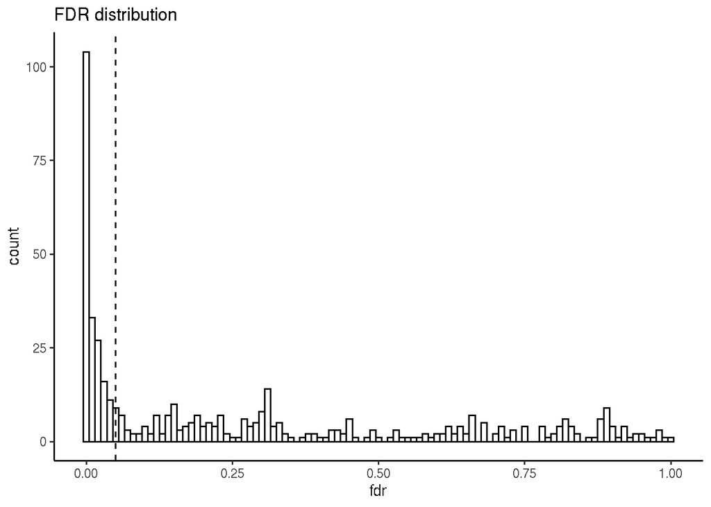

```r
df <- data.frame(
  exp="KD",
  fdr=tt$table$FDR)
# Change colors
ggplot(df, aes(x=fdr)) +
geom_histogram(color="black", fill="white", binwidth=0.01)+
geom_vline(xintercept=0.05, linetype="dashed")+
theme_classic()+
labs(title="FDR distribution")
```

## MA plot

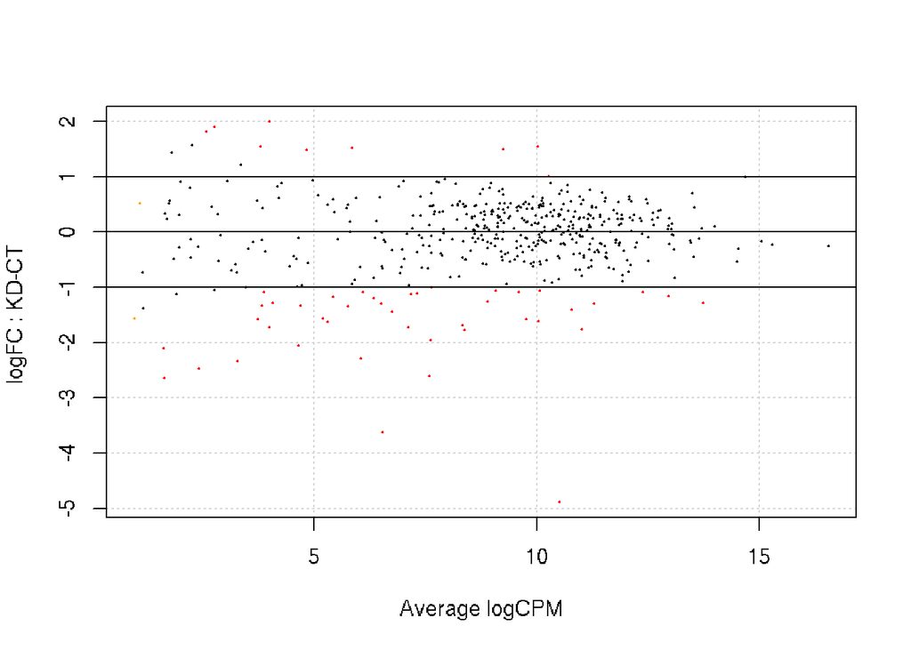

```r
deg<-rownames(tt)[tt$table$FDR <.05 &
                  abs(tt$table$logFC )>1 ]
plotSmear(d, de.tags=deg)
abline(h=c(-1,0,1))
```

## VULCANO PLOT (el último esfuerzo)

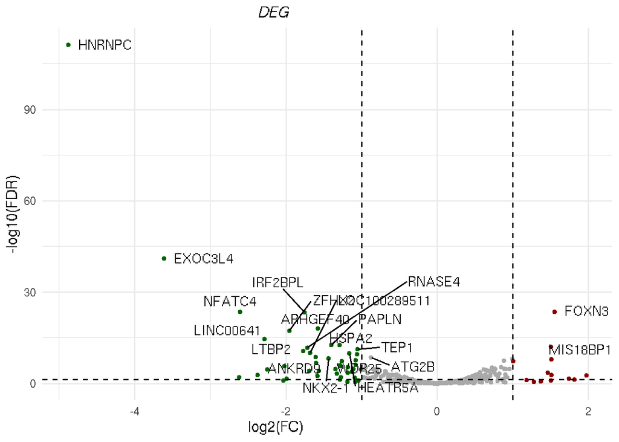

```r
y <-tt$table
tt10 <- topTags(de, n=20)

y$gene_color <- rep("grey", nrow(y))
y$gene_color[y$logFC>1] <-"red"
y$gene_color[y$logFC< (-1)]<-"green"

y$imp_genes<-NA

ii <- match(rownames(tt10), rownames(y))
y$imp_genes[ii]<-rownames(y)[ii]

library(ggrepel)

ggplot(y, aes(x=logFC, y=-log10(FDR))) +
  geom_point(aes(col=gene_color), cex= 1.2) +
  scale_color_manual(values=c("dark green","dark grey", "dark red")) +
  labs(title="DEG", x="log2(FC)", y="-log10(FDR)") +
  geom_vline(xintercept= c(-1, 1), colour= 'black', linetype= 'dashed') +
  geom_hline(yintercept= 1.30103, colour= 'black', linetype= 'dashed') +
  theme_minimal()+
  theme(legend.position = "none",
        plot.title = element_text(size = 12, face="italic", hjust=0.4),
        axis.title.x = element_text(color = "black", size=12, hjust = 0.4),
        axis.title.y = element_text(size =12, hjust = 0.5)) +
  geom_text_repel(data=y,
                  aes(x=logFC, y=-log10(FDR)),
                  label =y$imp_genes,
                  box.padding = unit(0.25, "lines"),
                  hjust =1,
                  max.overlaps = 50)
```

Exportamos los resultados en formato tabular, para futuros análisis:

```r
write.table() o write.csv():
write.csv(tt$table, file="red_edgeR.csv")
```